# 5XFAD_WT

Joseph Bundy

Analysis of NGS and proteomics data from 5xfad mouse brains - this analysis focuses only on the wt subset of the data

# Analysis of WT portion of 5XFAD mouse dataset

This report contains analyses of sex differences and developmental changes between female and male mice of 1, 2, and 4 months of age.

## Import and data cleaning

```r
library("DESeq2")
library("ggplot2")
library("RColorBrewer")
library("ashr")
library("scatterplot3d")
library("pheatmap")
library("gridExtra")
#library("venneuler")

library("eulerr")

in_data_RNA <- read.csv("input/5XFAD_counts_unnorm.csv", header = T, stringsAsFactors=FALSE)

sample_metadata= read.csv("input/5XFAD_NGS_meta.csv",header = T)
row.names(sample_metadata) = sample_metadata[,1]
sample_metadata = sample_metadata[2:61]
```

Clean data by splitting gene metadata columns from raw quantitative data

```r
row.names(in_data_RNA) = in_data_RNA[,1]
raw_data_RNA <- in_data_RNA[-c(1:3)]
geneinfo<- in_data_RNA[1:3]
```

Remove data from transgenic animals from dataset

```r
sample_metadata_wt = sample_metadata[,sample_metadata[3,] == "wt"]
sample_metadata_wt
```

|  | sample_1071D | sample_1071E | sample_1071G | sample_1071H | sample_1071I | sample_1071P | sample_1071Q | sample_1071X | sample_1072B | sample_1071T | sample_1050B | sample_1050C | sample_1052C | sample_1052I | sample_1053D | sample_1050Q | sample_1052O | sample_1053K | sample_1053L | sample_1053M | sample_1057A | sample_1057B | sample_1057D | sample_1056E | sample_1066D | sample_1048H | sample_1048I | sample_1048K | sample_1056G | … |
| --- | --- | --- | --- | --- | --- | --- | --- | --- | --- | --- | --- | --- | --- | --- | --- | --- | --- | --- | --- | --- | --- | --- | --- | --- | --- | --- | --- | --- | --- | --- |
| group | wt_1m_f | wt_1m_f | wt_1m_f | wt_1m_f | wt_1m_f | wt_1m_m | wt_1m_m | wt_1m_m | wt_1m_m | wt_1m_m | wt_2m_f | wt_2m_f | wt_2m_f | wt_2m_f | wt_2m_f | wt_2m_m | wt_2m_m | wt_2m_m | wt_2m_m | wt_2m_m | wt_4m_f | wt_4m_f | wt_4m_f | wt_4m_f | wt_4m_f | wt_4m_m | wt_4m_m | wt_4m_m | wt_4m_m | … |
| sex | female | female | female | female | female | male | male | male | male | male | female | female | female | female | female | male | male | male | male | male | female | female | female | female | female | male | male | male | male | … |
| genotype | wt | wt | wt | wt | wt | wt | wt | wt | wt | wt | wt | wt | wt | wt | wt | wt | wt | wt | wt | wt | wt | wt | wt | wt | wt | wt | wt | wt | wt | … |
| timepoint | 1 month | 1 month | 1 month | 1 month | 1 month | 1 month | 1 month | 1 month | 1 month | 1 month | 2 month | 2 month | 2 month | 2 month | 2 month | 2 month | 2 month | 2 month | 2 month | 2 month | 4 month | 4 month | 4 month | 4 month | 4 month | 4 month | 4 month | 4 month | 4 month | … |
| genotype_timepoint | wt_1m | wt_1m | wt_1m | wt_1m | wt_1m | wt_1m | wt_1m | wt_1m | wt_1m | wt_1m | wt_2m | wt_2m | wt_2m | wt_2m | wt_2m | wt_2m | wt_2m | wt_2m | wt_2m | wt_2m | wt_4m | wt_4m | wt_4m | wt_4m | wt_4m | wt_4m | wt_4m | wt_4m | wt_4m | … |
| sex_genotype | wt_f | wt_f | wt_f | wt_f | wt_f | wt_m | wt_m | wt_m | wt_m | wt_m | wt_f | wt_f | wt_f | wt_f | wt_f | wt_m | wt_m | wt_m | wt_m | wt_m | wt_f | wt_f | wt_f | wt_f | wt_f | wt_m | wt_m | wt_m | wt_m | … |
| sex_timepoint | f_1m | f_1m | f_1m | f_1m | f_1m | m_1m | m_1m | m_1m | m_1m | m_1m | f_2m | f_2m | f_2m | f_2m | f_2m | m_2m | m_2m | m_2m | m_2m | m_2m | f_4m | f_4m | f_4m | f_4m | f_4m | m_4m | m_4m | m_4m | m_4m | … |
| stage | NC | NC | NC | NC | NC | male | male | male | male | male | M | M | D | E | E | male | male | male | male | male | E | E | D | M | M | male | male | male | male | … |
| sort_number | 11 | 12 | 13 | 14 | 15 | 16 | 17 | 18 | 19 | 20 | 31 | 32 | 33 | 34 | 35 | 36 | 37 | 38 | 39 | 40 | 51 | 52 | 53 | 54 | 55 | 56 | 57 | 58 | 59 | … |
| input_reads | 11851553 | 13434385 | 12533981 | 13678093 | 13469341 | 4838419 | 14079457 | 15894189 | 13151501 | 12104220 | 11035014 | 15031106 | 23138464 | 7248478 | 16796012 | 26912945 | 25562072 | 15541724 | 16872034 | 18050841 | 21148183 | 14555582 | 12963476 | 16571076 | 8595497 | 22794221 | 16728941 | 10863440 | 12906774 | … |

[output cut: 23 more lines]

```r
raw_data_RNA_wt = raw_data_RNA[,sample_metadata[3,] == "wt"]
```

Generate sample table for DESeq2 containing relevant sample metadata

```r
SampleTable = data.frame(
SampleName = colnames(raw_data_RNA_wt),
group = as.character(as.matrix(sample_metadata_wt["group",])),
sex = as.character(as.matrix(sample_metadata_wt["sex",])),
timepoint = as.character(as.matrix(sample_metadata_wt["timepoint",])))
```

```r
ddsFullCountTable <- DESeqDataSetFromMatrix(
countData = as.matrix(raw_data_RNA_wt),
colData = SampleTable,
design = ~group)
dds = ddsFullCountTable
dds <- DESeq(dds)
```

Generate normalized counts for export and for figures

```r
normalizedCounts <- t( t(counts(dds)) / sizeFactors(dds) )
colnames(normalizedCounts) = SampleTable$group
```

## Functions for analysis

### Pairwise comparisons

This function generates two DESeq2 results objects for each comparison and generates both an excel file and a figure for each comparison. In addition to the regular results call, we call lfcshrink to generate LFCs that better represent the moderation of LFC in DESeq2 It may seem needless complicated, but without this function, this code would be duplicated many times.

```r
pairwise_comparison <- function(object, factor, group_1, group_2) {
  res = results(object, contrast=c(factor,group_1,group_2),
  alpha=0.05,
  independentFiltering = TRUE)
  #res = res[order(res$pvalue),]

  resLFC <- lfcShrink(object, contrast=c(factor,group_1,group_2), type="normal")

  table(res$padj > 0.05)
  out_file <-  cbind(geneinfo,res)
  out_file = out_file[order(out_file$pvalue),]
  write.csv(out_file,file = paste0("output/", group_1, "_vs_", group_2, ".csv"))
  DE = subset(out_file, out_file$padj < 0.05)
  UP = subset(out_file, out_file$padj < 0.05& out_file$log2FoldChange >0)
  DOWN = subset(out_file, out_file$padj < 0.05& out_file$log2FoldChange <0)


  plotMA(resLFC,ylim=c(-1,1),main=paste0(group_1, "_vs_", group_2), alpha = 0.05)
  textup = paste0("up ", length(UP$Associated.Gene.Name))
  textdown =  paste0("down ", length(DOWN$Associated.Gene.Name))
  textDE =  paste0(length(DE$Associated.Gene.Name), " DE")
  text(x = .1, y =0.75, label = textup)
  text(x = .1, y =-0.75, label = textdown)
  text(x = 100000, y =0.9, label = textDE)

  return(data.frame("Gene.ID" = DE$Gene.ID,
                    "Name" = DE$Associated.Gene.Name,
                    "L2FC" = DE$log2FoldChange,
                    "pvalue" = DE$pvalue,
                    "padj" = DE$padj))
}
```

### PCA plots

This function is basically the same as the PCA function built into DESeq, but allows you to return more than just the top 2 principal components should you choose.

```r
JLB_PCA = function(object, intgroup="condition", ntop=500, returnData=FALSE)
{
  # calculate the variance for each gene
  rv <- rowVars(assay(object))

  # select the ntop genes by variance
  select <- order(rv, decreasing=TRUE)[seq_len(min(ntop, length(rv)))]

  # perform a PCA on the data in assay(x) for the selected genes
  pca <- prcomp(t(assay(object)[select,]))

  # the contribution to the total variance for each component
  percentVar <- pca$sdev^2 / sum( pca$sdev^2 )

  if (!all(intgroup %in% names(colData(object)))) {
    stop("the argument 'intgroup' should specify columns of colData(dds)")
  }

  intgroup.df <- as.data.frame(colData(object)[, intgroup, drop=FALSE])

  # add the intgroup factors together to create a new grouping factor
  group <- if (length(intgroup) > 1) {
    factor(apply( intgroup.df, 1, paste, collapse=" : "))
  } else {
    colData(object)[[intgroup]]
  }

  # assembly the data for the plot
  d <- data.frame(PC1=pca$x[,1], PC2=pca$x[,2],PC3=pca$x[,3],PC4=pca$x[,4],PC5=pca$x[,5], group=group, intgroup.df, name=colnames(object))

  if (returnData) {
    attr(d, "percentVar") <- percentVar[1:5]
    return(d)
  }

  ggplot(data=d, aes_string(x="PC1", y="PC2", color="group")) + geom_point(size=3) +
    xlab(paste0("PC1: ",round(percentVar[1] * 100),"% variance")) +
    ylab(paste0("PC2: ",round(percentVar[2] * 100),"% variance")) +
    coord_fixed()
}
```

Function for 9 panel PCA plot

```r
threewaypca <- function(PCA_object, color_map, pch_map) {
empty1<- ggplot()+geom_point(aes(1,1), colour="white") +
  geom_text(aes(x = 1, y = 1, label = "PC1"), color="black", size=10, parse = TRUE)+
  theme(
    plot.background = element_blank(),
    panel.grid.major = element_blank(),
    panel.grid.minor = element_blank(),
    panel.border = element_blank(),
    panel.background = element_blank(),
    axis.title.x = element_blank(),
    axis.title.y = element_blank(),
    axis.text.x = element_blank(),
    axis.text.y = element_blank(),
    axis.ticks = element_blank()
  )


empty2<- ggplot()+geom_point(aes(1,1), colour="white") +
  geom_text(aes(x = 1, y = 1, label = "PC2"), color="black", size=10, parse = TRUE)+
  theme(
    plot.background = element_blank(),
    panel.grid.major = element_blank(),
    panel.grid.minor = element_blank(),
    panel.border = element_blank(),
    panel.background = element_blank(),
    axis.title.x = element_blank(),
    axis.title.y = element_blank(),
    axis.text.x = element_blank(),
    axis.text.y = element_blank(),
    axis.ticks = element_blank()
  )
empty3<- ggplot()+geom_point(aes(1,1), colour="white") +
  geom_text(aes(x = 1, y = 1, label = "PC3"), color="black", size=10, parse = TRUE)+
  theme(
    plot.background = element_blank(),
    panel.grid.major = element_blank(),
    panel.grid.minor = element_blank(),
    panel.border = element_blank(),
    panel.background = element_blank(),
    axis.title.x = element_blank(),
    axis.title.y = element_blank(),
    axis.text.x = element_blank(),
    axis.text.y = element_blank(),
    axis.ticks = element_blank()
  )

plot1 = ggplot(PCA_object, aes(PC1, PC2,fill = factor(color_map), pch = factor(pch_map))) + geom_point( size=4) +
  scale_colour_manual(values=c("#FFB6C1", "#5a5aff"))+
  scale_fill_manual(values=c("#FFB6C1", "#5a5aff"), labels = c("females", "males"))+
  scale_shape_manual(values = c(21,24,22), labels = c("1month", "2month", "4month"))+
  xlab(paste0("PC1: ",percentVar[1],"% variance")) +
  ylab(paste0("PC2: ",percentVar[2],"% variance")) +
guides(fill=guide_legend(title = "sex", override.aes = list(colour = c("#FFB6C1", "#5a5aff"))), shape = guide_legend(title = "age"))+
  theme(legend.position=c(1.3, 0.5))

plot2 = ggplot(PCA_object, aes(PC1, PC3,fill = factor(color_map), pch = factor(pch_map))) + geom_point( size=4) +
  scale_colour_manual(values=c("#FFB6C1", "#5a5aff"))+
  scale_fill_manual(values=c("#FFB6C1", "#5a5aff"))+
  scale_shape_manual(values = c(21,24,22))+
  xlab(paste0("PC1: ",percentVar[1],"% variance")) +
  ylab(paste0("PC3: ",percentVar[3],"% variance")) +
  theme(legend.position = "none")

plot3 = ggplot(PCA_object, aes(PC2, PC1,fill = factor(color_map), pch = factor(pch_map))) + geom_point( size=4) +
  scale_colour_manual(values=c("#FFB6C1", "#5a5aff"))+
  scale_fill_manual(values=c("#FFB6C1", "#5a5aff"))+
  scale_shape_manual(values = c(21,24,22))+
  xlab(paste0("PC2: ",percentVar[2],"% variance")) +
  ylab(paste0("PC1: ",percentVar[1],"% variance")) +
  theme(legend.position = "none")

plot4 = ggplot(PCA_object, aes(PC2, PC3,fill = factor(color_map), pch = factor(pch_map))) + geom_point( size=4) +
  scale_colour_manual(values=c("#FFB6C1", "#5a5aff"))+
  scale_fill_manual(values=c("#FFB6C1", "#5a5aff"))+
  scale_shape_manual(values = c(21,24,22))+
  xlab(paste0("PC2: ",percentVar[2],"% variance")) +
  ylab(paste0("PC3: ",percentVar[3],"% variance")) +
  theme(legend.position = "none")

plot5 = ggplot(PCA_object, aes(PC3, PC1,fill = factor(color_map), pch = factor(pch_map))) + geom_point( size=4) +
  scale_colour_manual(values=c("#FFB6C1", "#5a5aff"))+
  scale_fill_manual(values=c("#FFB6C1", "#5a5aff"))+
  scale_shape_manual(values = c(21,24,22))+
  xlab(paste0("PC3: ",percentVar[3],"% variance")) +
  ylab(paste0("PC1: ",percentVar[1],"% variance")) +
  theme(legend.position = "none")

plot6 = ggplot(PCA_object, aes(PC3, PC2,fill = factor(color_map), pch = factor(pch_map))) + geom_point( size=4) +
  scale_colour_manual(values=c("#FFB6C1", "#5a5aff"))+
  scale_fill_manual(values=c("#FFB6C1", "#5a5aff"))+
  scale_shape_manual(values = c(21,24,22))+
  xlab(paste0("PC3: ",percentVar[3],"% variance")) +
  ylab(paste0("PC2: ",percentVar[2],"% variance")) +
  theme(legend.position = "none")

grid.arrange(empty1, plot3, plot5, plot1, empty2, plot6, plot2, plot4, empty3,  ncol=3, nrow=3, widths=c(2,2,2), heights=c(2,2,2))
}
```

### Venn Diagrams

Function for a two set venn diagram

```r
venn.plot_2 <- function(name1, name2, list1, list2){
colors <- brewer.pal(2, "Set1")
v <- euler(c(
"A"=length(setdiff(list1,list2)),
"B"=length(setdiff(list2,list1)),
"A&B"=length(intersect(list1,list2))
))
#v$labels <- c(name1, name2, name3)
plot(v,
labels = list(labels = c(name1, name2)),
quantities = list(type = "counts"))
}
```

Function for a three set venn diagram

```r
venn.plot_3 <- function(name1, name2, name3, list1, list2, list3){
colors <- brewer.pal(3, "Set1")
v <- euler(c(
"A"=length(setdiff(list1,union(list2,list3))),
"B"=length(setdiff(list2,union(list1,list3))),
"C"=length(setdiff(list3,union(list1,list2))),
"A&B" = length(setdiff(intersect(list1,list2),list3)),
"A&C" = length(setdiff(intersect(list1,list3),list2)),
"B&C" = length(setdiff(intersect(list2,list3),list1)),
"A&B&C" = length(intersect(intersect(list1,list2),list3))
))
#v$labels <- c(name1, name2, name3)
plot(v,
labels = list(labels = c(name1, name2, name3)),
quantities = list(type = "counts"))
}
```

## Quality Control and Data Exploration

### Library Size

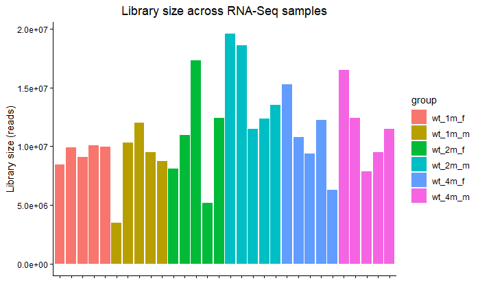

```r
hist_data = data.frame(
"samples" = as.character(as.matrix(names(sample_metadata_wt))),
"group" = as.character(as.matrix(sample_metadata_wt["group",])),
"unnorm_sum" = colSums(counts(dds, normalized=FALSE)),
"norm_sum" = colSums(counts(dds, normalized=TRUE)))

#relevel names so that they're respected in graph
hist_data$samples <- as.character(hist_data$samples)
hist_data$samples <- factor(hist_data$samples, levels=unique(hist_data$samples))


ggplot(hist_data) +
  aes(x = samples, y = unnorm_sum, fill = group) +
  geom_col()+
  labs(size = 7,
       x = "",
       y = "Library size (reads)",
       title = "Library size across RNA-Seq samples")+
  theme(
        #axis.text.x=element_text(colour="black", size = 10,angle = 45, hjust = 1),
        axis.text.x=element_blank(),
        axis.text.y=element_text(colour="black"),
        axis.ticks = element_line(colour="black"),
        plot.title = element_text(hjust = 0.5),
        plot.background = element_blank(),
        panel.grid.major = element_blank(),
        panel.grid.minor = element_blank(),
        panel.border = element_blank(),
        panel.background = element_blank(),
        axis.line = element_line(size=.4)
  )
```

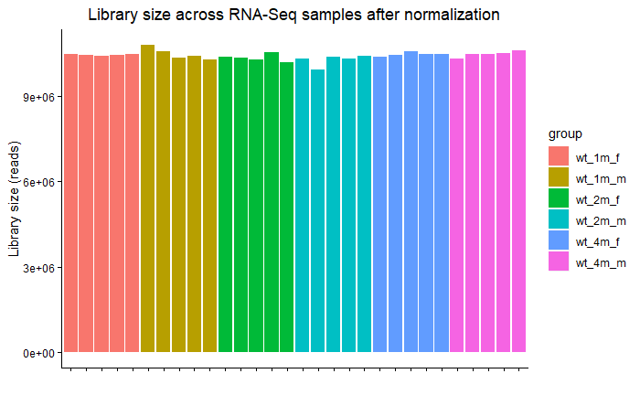

```r
ggplot(hist_data) +
  aes(x = samples, y = norm_sum, fill = group) +
  geom_col()+
  labs(size = 7,
       x = "",
       y = "Library size (reads)",
       title = "Library size across RNA-Seq samples after normalization")+
  theme(
      #axis.text.x=element_text(colour="black", size = 10,angle = 45, hjust = 1),
       axis.text.x=element_blank(),
        axis.text.y=element_text(colour="black"),
        axis.ticks = element_line(colour="black"),
        plot.title = element_text(hjust = 0.5),
        plot.background = element_blank(),
        panel.grid.major = element_blank(),
        panel.grid.minor = element_blank(),
        panel.border = element_blank(),
        panel.background = element_blank(),
        axis.line = element_line(size=.4)
  )
```

```r
NA
NA
```

### Sample Correlations

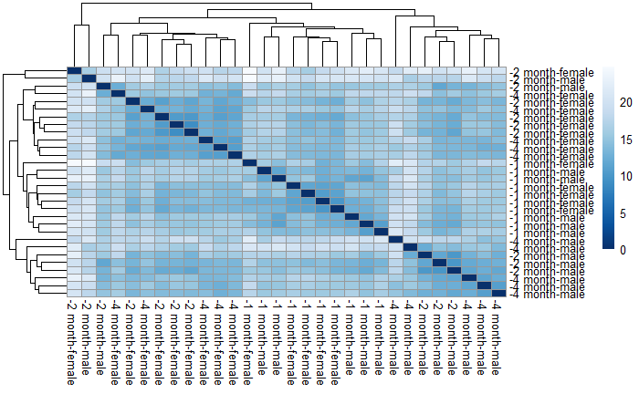

```r
rld <- rlogTransformation(dds, blind=FALSE)
sampleDists <- dist( t( assay(rld) ) )
sampleDistMatrix <- as.matrix( sampleDists )
rownames(sampleDistMatrix) <- paste( rld$genotype, rld$timepoint,rld$sex, sep="-" )
colnames(sampleDistMatrix) <- paste( rld$genotype, rld$timepoint,rld$sex, sep="-" )
colors <- colorRampPalette( rev(brewer.pal(9, "Blues")) )(255)
pheatmap(sampleDistMatrix,
         clustering_distance_rows=sampleDists,
         clustering_distance_cols=sampleDists,
         col=colors)
```

### PCA

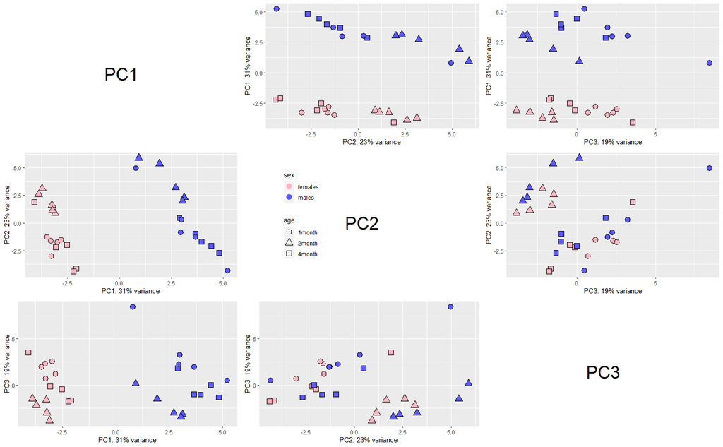

```r
PCA_object <- JLB_PCA(rld, intgroup = c( "sex","timepoint"), returnData=TRUE, n = 500)
percentVar <- round(100 * attr(PCA_object, "percentVar"))

pch = as.factor(c(rep(16,10),rep(17,10),rep(15,10)))
col = c(rep(c(rep("#5a5aff",5),rep("#FFB6C1",5)),3))


threewaypca(PCA_object = PCA_object, color_map = col, pch_map = pch)
```

```r
NA
NA
```

## Pairwise Comparisons

### Differences between Sexes at each month

#### 1 month Females vs Males

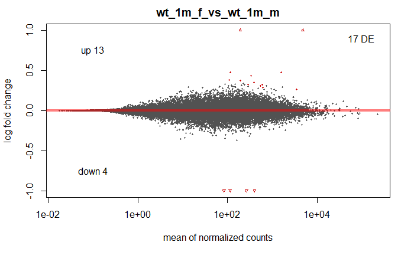

```r
wt_1m_f_vs_wt_1m_m = pairwise_comparison(object = dds, factor = "group", group_1 = "wt_1m_f", group_2 = "wt_1m_m")
```

```r
wt_1m_f_vs_wt_1m_m
```

| Gene.ID | Name | L2FC | pvalue | padj |
| --- | --- | --- | --- | --- |
| ENSMUSG00000086503 | Xist | 9.1963731 | 0.000000e+00 | 0.000000e+00 |
| ENSMUSG00000085715 | Tsix | 5.1422535 | 2.809088e-84 | 1.821553e-80 |
| ENSMUSG00000069045 | Ddx3y | -11.5146786 | 3.817045e-36 | 1.650108e-32 |
| ENSMUSG00000069049 | Eif2s3y | -11.4755996 | 7.656781e-36 | 2.482520e-32 |
| ENSMUSG00000068457 | Uty | -9.7483904 | 2.973950e-26 | 7.713831e-23 |
| ENSMUSG00000056673 | Kdm5d | -9.7212535 | 3.612759e-26 | 7.808980e-23 |
| ENSMUSG00000035150 | Eif2s3x | 0.5052142 | 1.809952e-21 | 3.353324e-18 |
| ENSMUSG00000037369 | Kdm6a | 0.5139753 | 1.972801e-08 | 3.198156e-05 |
| ENSMUSG00000025332 | Kdm5c | 0.3532857 | 1.390357e-07 | 2.003504e-04 |
| ENSMUSG00000024793 | Tnfrsf25 | 0.8472347 | 3.319871e-07 | 4.305541e-04 |

[output cut: 7 more lines]

#### 2 month Females vs Males

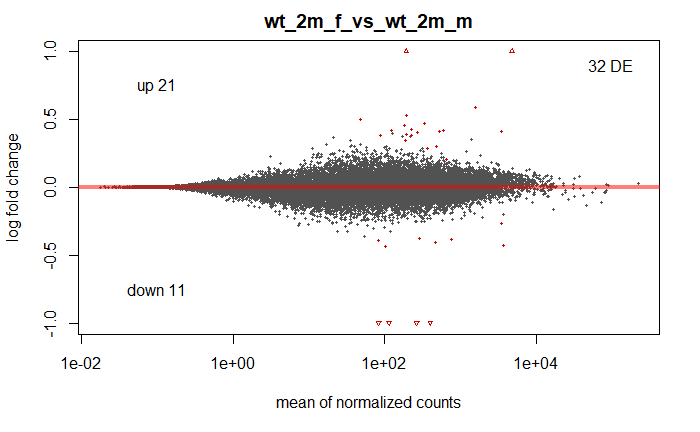

```r
wt_2m_f_vs_wt_2m_m = pairwise_comparison(object = dds, factor = "group",group_1 = "wt_2m_f", group_2 = "wt_2m_m")
```

```r
wt_2m_f_vs_wt_2m_m
```

| Gene.ID | Name | L2FC | pvalue | padj |
| --- | --- | --- | --- | --- |
| ENSMUSG00000086503 | Xist | 9.3775095 | 0.000000e+00 | 0.000000e+00 |
| ENSMUSG00000085715 | Tsix | 5.5773298 | 1.787333e-127 | 1.331563e-123 |
| ENSMUSG00000069045 | Ddx3y | -12.0110532 | 3.449831e-39 | 1.713416e-35 |
| ENSMUSG00000035150 | Eif2s3x | 0.6193229 | 1.242381e-33 | 4.627869e-30 |
| ENSMUSG00000069049 | Eif2s3y | -10.8547496 | 2.906315e-32 | 8.660818e-29 |
| ENSMUSG00000056673 | Kdm5d | -10.2019386 | 1.112123e-28 | 2.761772e-25 |
| ENSMUSG00000068457 | Uty | -9.1528727 | 2.274774e-23 | 4.842019e-20 |
| ENSMUSG00000079297 | Gm2223 | 0.6243468 | 6.854924e-13 | 1.276730e-09 |
| ENSMUSG00000000787 | Ddx3x | 0.4489298 | 1.297204e-11 | 2.147594e-08 |
| ENSMUSG00000037369 | Kdm6a | 0.5516602 | 2.858232e-10 | 4.258766e-07 |

[output cut: 22 more lines]

#### 4 month Females vs Males

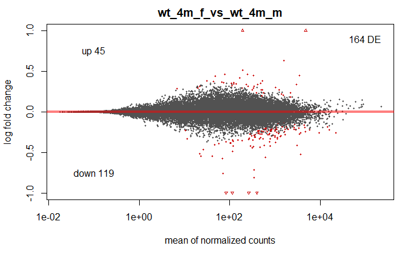

```r
wt_4m_f_vs_wt_4m_m = pairwise_comparison(object = dds, factor = "group",group_1 = "wt_4m_f", group_2 = "wt_4m_m")
```

```r
wt_4m_f_vs_wt_4m_m
```

| Gene.ID | Name | L2FC | pvalue | padj |
| --- | --- | --- | --- | --- |
| ENSMUSG00000086503 | Xist | 9.2420504 | 0.000000e+00 | 0.000000e+00 |
| ENSMUSG00000085715 | Tsix | 5.6957903 | 9.105897e-94 | 7.003801e-90 |
| ENSMUSG00000035150 | Eif2s3x | 0.6716642 | 1.824362e-38 | 9.354720e-35 |
| ENSMUSG00000069049 | Eif2s3y | -9.3013635 | 1.201878e-37 | 4.622121e-34 |
| ENSMUSG00000069045 | Ddx3y | -10.8424026 | 1.585973e-33 | 4.879405e-30 |
| ENSMUSG00000056673 | Kdm5d | -9.5569209 | 2.358931e-25 | 6.047906e-22 |
| ENSMUSG00000068457 | Uty | -9.2497216 | 8.084211e-24 | 1.776563e-20 |
| ENSMUSG00000019916 | P4ha1 | -0.6081384 | 4.977343e-22 | 9.570809e-19 |
| ENSMUSG00000029657 | Hsph1 | -0.4494069 | 3.270111e-14 | 5.589346e-11 |
| ENSMUSG00000000787 | Ddx3x | 0.4942639 | 1.101922e-13 | 1.695086e-10 |

[output cut: 154 more lines]

#### Set analysis

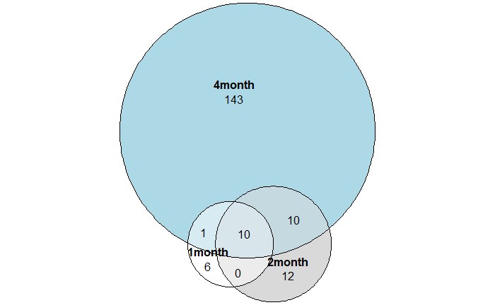

```r
venn.plot_3("1month",
"2month",
"4month",
wt_1m_f_vs_wt_1m_m$Gene.ID,
wt_2m_f_vs_wt_2m_m$Gene.ID,
wt_4m_f_vs_wt_4m_m$Gene.ID)
```

### Difference between Ages

#### By Sex

##### 1 vs 2 month

###### Females

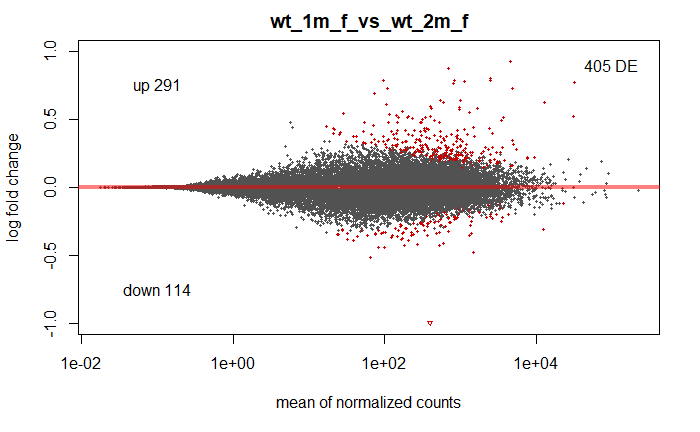

```r
wt_1m_f_vs_wt_2m_f = pairwise_comparison(object = dds, factor = "group", group_1 = "wt_1m_f", group_2 = "wt_2m_f")
```

```r
wt_1m_f_vs_wt_2m_f
```

| Gene.ID | Name | L2FC | pvalue | padj |
| --- | --- | --- | --- | --- |
| ENSMUSG00000024810 | Il33 | -1.3115013 | 1.316767e-51 | 2.025582e-47 |
| ENSMUSG00000027375 | Mal | 1.0445142 | 2.037781e-44 | 1.567360e-40 |
| ENSMUSG00000026879 | Gsn | 0.9654951 | 1.673744e-43 | 8.582401e-40 |
| ENSMUSG00000006782 | Cnp | 0.7862823 | 1.196490e-38 | 4.601403e-35 |
| ENSMUSG00000076439 | Mog | 0.8874045 | 1.526027e-31 | 4.694976e-28 |
| ENSMUSG00000037625 | Cldn11 | 0.9120633 | 4.276885e-27 | 1.096522e-23 |
| ENSMUSG00000052229 | Gpr17 | 0.8971868 | 1.268580e-24 | 2.787794e-21 |
| ENSMUSG00000031425 | Plp1 | 0.9273643 | 2.642320e-23 | 5.080852e-20 |
| ENSMUSG00000009828 | Ick | 0.6325397 | 3.097081e-23 | 5.293600e-20 |
| ENSMUSG00000027858 | Tspan2 | 0.9943609 | 4.524150e-22 | 6.959499e-19 |

[output cut: 395 more lines]

###### Males

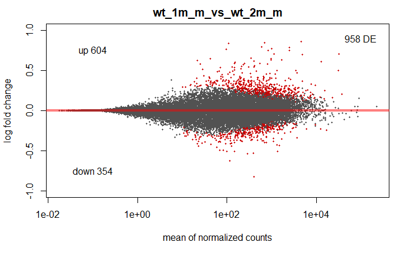

```r
wt_1m_m_vs_wt_2m_m = pairwise_comparison(object = dds, factor = "group", group_1 = "wt_1m_m", group_2 = "wt_2m_m")
```

```r
wt_1m_m_vs_wt_2m_m
```

| Gene.ID | Name | L2FC | pvalue | padj |
| --- | --- | --- | --- | --- |
| ENSMUSG00000026879 | Gsn | 0.9353419 | 2.703271e-42 | 4.158442e-38 |
| ENSMUSG00000027375 | Mal | 0.9693578 | 9.699346e-39 | 7.460252e-35 |
| ENSMUSG00000006782 | Cnp | 0.7569857 | 3.640728e-36 | 1.866844e-32 |
| ENSMUSG00000024810 | Il33 | -1.0004562 | 1.492490e-31 | 5.739743e-28 |
| ENSMUSG00000076439 | Mog | 0.8472709 | 1.218645e-29 | 3.749285e-26 |
| ENSMUSG00000037625 | Cldn11 | 0.9092067 | 3.422720e-27 | 8.775285e-24 |
| ENSMUSG00000036634 | Mag | 0.7010198 | 4.966556e-25 | 1.091436e-21 |
| ENSMUSG00000009828 | Ick | 0.6082790 | 6.390901e-23 | 1.228890e-19 |
| ENSMUSG00000032517 | Mobp | 0.6917654 | 7.324330e-20 | 1.251891e-16 |
| ENSMUSG00000031425 | Plp1 | 0.8448061 | 1.277752e-19 | 1.965567e-16 |

[output cut: 948 more lines]

###### Set analysis

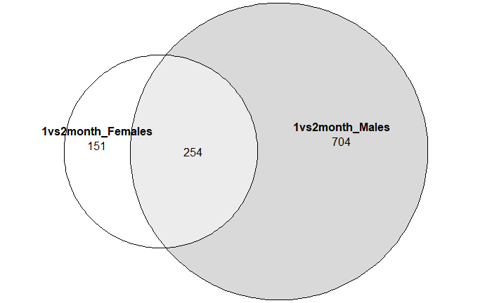

```r
venn.plot_2("1vs2month_Females",
"1vs2month_Males",
wt_1m_f_vs_wt_2m_f$Gene.ID,
wt_1m_m_vs_wt_2m_m$Gene.ID)
```

##### 2 vs 4 month

###### Females

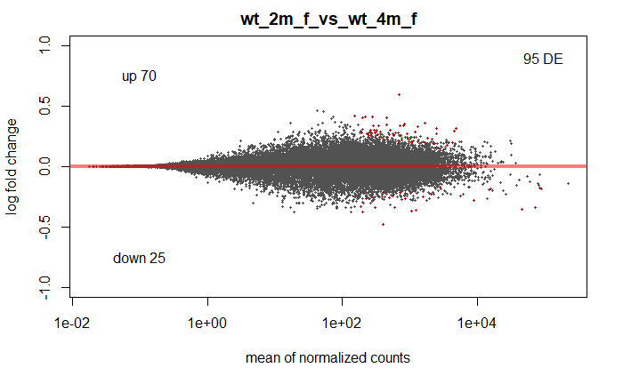

```r
wt_2m_f_vs_wt_4m_f = pairwise_comparison(object = dds, factor = "group", group_1 = "wt_2m_f", group_2 = "wt_4m_f")
```

```r
wt_2m_f_vs_wt_4m_f
```

| Gene.ID | Name | L2FC | pvalue | padj |
| --- | --- | --- | --- | --- |
| ENSMUSG00000026879 | Gsn | 0.6810507 | 1.198380e-19 | 1.554179e-15 |
| ENSMUSG00000024810 | Il33 | -0.5372197 | 6.650242e-13 | 4.312350e-09 |
| ENSMUSG00000039601 | Rcan2 | -0.4078773 | 6.171123e-09 | 2.667777e-05 |
| ENSMUSG00000036634 | Mag | 0.3996715 | 8.919688e-09 | 2.891986e-05 |
| ENSMUSG00000027199 | Gatm | -0.4114870 | 1.321020e-08 | 3.426462e-05 |
| ENSMUSG00000006782 | Cnp | 0.3429626 | 1.937375e-08 | 4.187635e-05 |
| ENSMUSG00000059991 | Nptx2 | 0.4984601 | 1.534105e-07 | 2.842258e-04 |
| ENSMUSG00000076439 | Mog | 0.4068792 | 2.553902e-07 | 3.774040e-04 |
| ENSMUSG00000055540 | Epha6 | 0.4849917 | 2.619042e-07 | 3.774040e-04 |
| ENSMUSG00000003534 | Ddr1 | 0.3838039 | 8.528646e-07 | 1.011903e-03 |

[output cut: 85 more lines]

###### Males

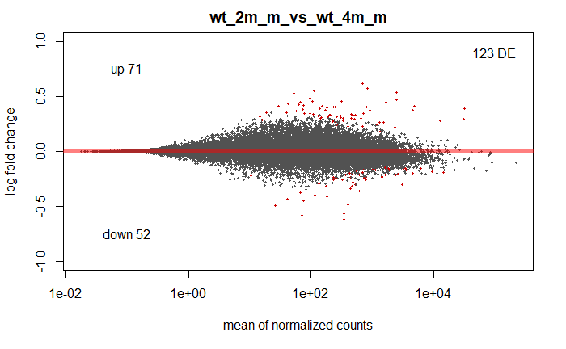

```r
wt_2m_m_vs_wt_4m_m = pairwise_comparison(object = dds, factor = "group", group_1 = "wt_2m_m", group_2 = "wt_4m_m")
```

```r
wt_2m_m_vs_wt_4m_m
```

| Gene.ID | Name | L2FC | pvalue | padj |
| --- | --- | --- | --- | --- |
| ENSMUSG00000026879 | Gsn | 0.7005685 | 5.900993e-22 | 1.050141e-17 |
| ENSMUSG00000076439 | Mog | 0.6623078 | 1.585825e-17 | 1.411067e-13 |
| ENSMUSG00000024810 | Il33 | -0.5511652 | 4.451274e-14 | 2.640496e-10 |
| ENSMUSG00000037625 | Cldn11 | 0.6350259 | 8.010462e-14 | 3.563855e-10 |
| ENSMUSG00000006782 | Cnp | 0.4481002 | 1.507176e-13 | 5.364342e-10 |
| ENSMUSG00000036634 | Mag | 0.5006347 | 3.524685e-13 | 1.045422e-09 |
| ENSMUSG00000019916 | P4ha1 | -0.3934468 | 8.025022e-11 | 2.040190e-07 |
| ENSMUSG00000020150 | Gamt | 0.7650462 | 1.067801e-10 | 2.375322e-07 |
| ENSMUSG00000035551 | Igfbpl1 | 1.3195312 | 9.721221e-09 | 1.661183e-05 |
| ENSMUSG00000027375 | Mal | 0.4285525 | 1.041375e-08 | 1.661183e-05 |

[output cut: 113 more lines]

###### Set analysis

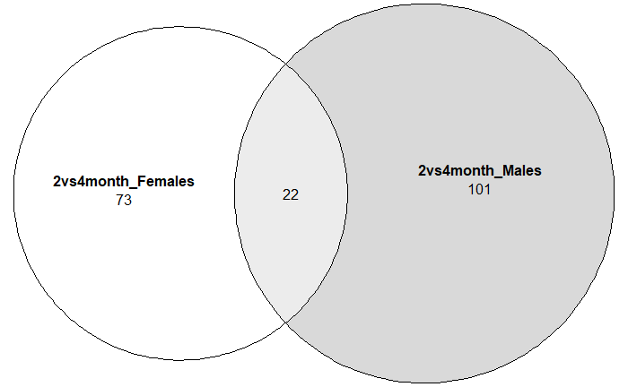

```r
venn.plot_2("2vs4month_Females",
"2vs4month_Males",
wt_2m_f_vs_wt_4m_f$Gene.ID,
wt_2m_m_vs_wt_4m_m$Gene.ID)
```

#### Pooled analysis

Separate DESeq2 object with sex and timepoint info split into separate variables - allows the contrast of different ages while accounting for (pooling) sex-differences in expression

```r
ddsFullCountTable <- DESeqDataSetFromMatrix(
  countData = as.matrix(raw_data_RNA_wt),
  colData = SampleTable,
  design = ~sex + timepoint)
dds_pooled = ddsFullCountTable

dds_pooled_pairwise <- DESeq(dds_pooled)
```

##### 1 vs 2 month

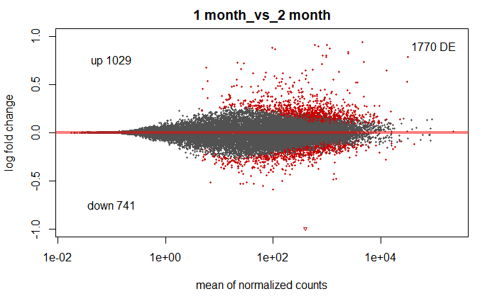

```r
month1_vs_month2 = pairwise_comparison(object = dds_p, factor = "timepoint", group_1 = "1 month", group_2 = "2 month")
```

```r
month1_vs_month2
```

[output not shown]

[output cut: 990 more lines]

##### 2 vs 4 month

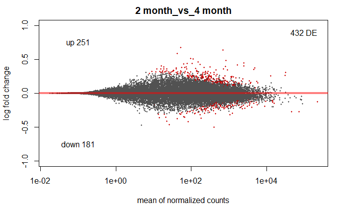

```r
month2_vs_month4 = pairwise_comparison(object = dds_p, factor = "timepoint",group_1 = "2 month", group_2 = "4 month")
```

```r
month2_vs_month4
```

[output not shown]

[output cut: 422 more lines]

##### Set Analysis

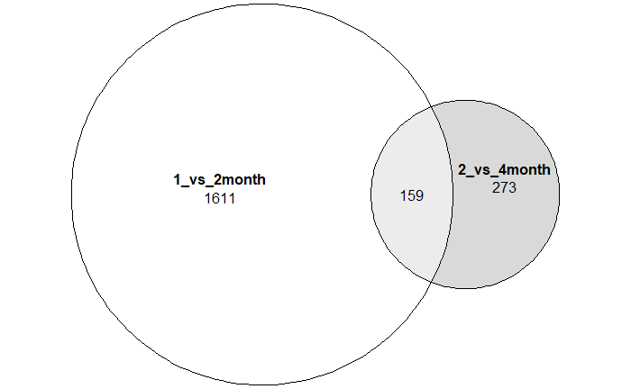

```r
venn.plot_2("1_vs_2month",
"2_vs_4month",
month1_vs_month2$Gene.ID,
month2_vs_month4$Gene.ID)
```

## LRT for temporal changes in expression

Rebuild the DESeq2 object with a design formula that includes both sex and time as factors, then we include only “sex” in the reduced formula, thus testing only for genes that change significantly as a function of the “age” factor.

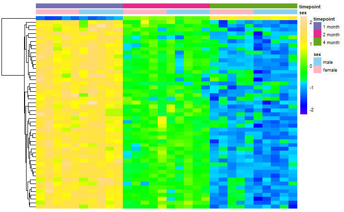

```r
dds_pooled_LRT <- DESeq(dds_pooled, reduced = ~sex, test = "LRT")
res_LRT = results(dds_pooled_LRT, alpha = 0.05, independentFiltering = TRUE)

#generate some factors for the heatmap key
ann_colors = list(
  sex = c(male = "#89cff0", female = "#FFB6C1"),
  timepoint = c("1 month" = "#7570B3", "2 month" = "#E7298A", "4 month" = "#66A61E")
)

out_file <-  cbind(geneinfo,res_LRT)
write.csv(out_file,file = "output/LRT_changes_over_time.csv")

siggenes <- head(order(res_LRT$padj),50)
mat <- assay(rld)[ siggenes, ]
names <- mcols(rld)[ siggenes, ]
names <- names[,1]
mat <- mat - rowMeans(mat)
df <- as.data.frame(colData(rld)[,c("sex","timepoint")])
pheatmap(scale = "row", fontsize = 7,mat, annotation_col=df, cluster_col=FALSE, show_rownames = FALSE,show_colnames = FALSE,  annotation_colors = ann_colors, col=topo.colors(100), border_color = NA)
```

## LRT for Sex:Age Interaction

Rebuild the DESeq2 object with a design formula that includes sex, time, and a sex:time interraction term - all but the last of which will be entered in the “reduced” formula

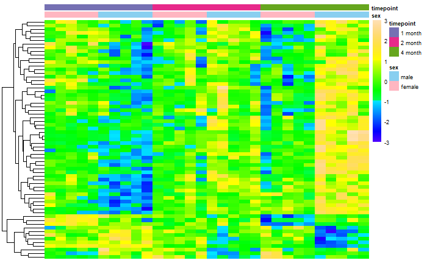

```r
ddsFullCountTable <- DESeqDataSetFromMatrix(
  countData = as.matrix(raw_data_RNA_wt),
  colData = SampleTable,
  design = ~sex+timepoint+sex:timepoint)
  dds_interaction = ddsFullCountTable
  mcols(dds_interaction) <- DataFrame(mcols(dds_interaction), geneinfo)
 dds_interaction <- DESeq(dds_interaction, reduced = ~sex+timepoint, test = "LRT")
 res_interaction = results(dds_interaction, alpha = 0.05)

out_file <-  cbind(geneinfo,res_interaction)
write.csv(out_file,file = "output/sex_by_time.csv")


siggenes <- head(order(res_interaction$padj),table(res_interaction$padj > 0.05)[1])
mat <- assay(rld)[ siggenes, ]
names <- mcols(rld)[ siggenes, ]
names <- names[,1]
mat <- mat - rowMeans(mat)
df <- as.data.frame(colData(rld)[,c("sex","timepoint")])
pheatmap(scale = "row", fontsize = 7,mat, annotation_col=df, cluster_col=FALSE, show_rownames = FALSE,show_colnames = FALSE,  annotation_colors = ann_colors, col=topo.colors(100), border_color = NA)
```